# 動物實驗設計與研究方法

Week 03｜動物模式的應用、限制與結論範圍

陳敬元 Jing-Yuan Chen, DVM, PhD

jychen@niar.org.tw

國家實驗研究院國家生物模式中心

宜蘭大學生物技術與動物科學系

September 22, 2026

# 01｜動物模式可以回答什麼

## 本週要處理的三個問題

1. 動物在研究設計中扮演什麼角色？
2. 研究條件如何限制結論的範圍？
3. 讀自己的 anchor paper 時，哪些結論有研究條件與資料支持，哪些需要保留？

## 今天的節奏

1. **建立判斷標準**：分清實驗手段、推論角色與操作條件
2. **經典案例解析**：實驗條件如何左右研究結論（DSS、環境菌相、田間試驗）
3. **掌握評估工具**：釐清推論的限制與範圍、認識 EDA 工具與抓出論文漏洞
4. **實作演練**：用自己的 Anchor paper，檢視研究條件並劃出合理推論範圍

## 本週核心概念

- 動物研究常見的三種誤解

[figure not shown]

**誤解 1：目標情境的 1:1 複製**

[figure not shown]

**誤解 2：論文結論的無限擴充**

[figure not shown]

**誤解 3：審查通關的護身符**

動物研究的結論，需要回到：**研究問題與實際使用的條件。**

圖片來源：[imgflip.com](https://imgflip.com/) 與 [xkcd.tw](https://xkcd.tw/1217)

## 從「該不該用」，到「代表了什麼」

**上週回顧：動物使用的正當性**

- 為什麼非得用動物？（科學必要性）
- 動物承受了什麼？（福祉與疼痛評估）
- 設計品質能否支持動物的使用？

### 這週的核心推進 ➔

**這個動物模式，到底代表研究問題中的哪一部分？**

## 先讓我們分清楚

**動物實驗**

(`Method/Procedure`)

- 核心問題：研究做了什麼操作？
- 本質：研究活動 (處置、採樣、測量、觀察)。

[figure not shown]

**動物模式**

(`Representation / Validity`)

- 核心問題：這組條件要回答什麼？
- 本質：目標情境的局部代理 (surrogate)。

[figure not shown]

**先看研究問題，再判斷動物在其中的角色**  
(同一篇研究可能同時有兩種角色)。

## 先從研究問題定位動物的角色

| 角色類型 | 核心特徵 | 實務案例 |
| --- | --- | --- |
| **目標物種研究** | 直接關心動物本身的生長、健康、生產或福祉 | 肉豬田間疫苗試驗 |
| **動物模式** | 以特定動物條件，觀察目標情境的一部分機制 | 以 DSS 小鼠觀察腸道屏障受損與發炎反應 |
| 動物來源材料/ 觀察性 | 研究者通常未對動物施加人為實驗處置 | 比較不同季節屠宰豬肉的風味與肉質 |

💡 先確認研究問題，再判斷動物、材料或族群在其中扮演什麼角色。

## 動物模式的基本角色

動物模式是研究者選定的一組條件，用來觀察目標情境中某些可研究的機制或結果。

常見條件包括：

- **動物來源與遺傳背景**：物種 (species)、品系 (strain)、特定建立的動物品系 (line) 或品種 (breed)
- **生理與疾病狀態**：年齡、性別、體重、生理狀態與疾病階段
- **飼養與微生物背景**：飼養條件、飲食、環境或是體內的微生物相
- **實驗處置程序**：介入、攻毒或誘導、暴露與操作程序
- **指標與取樣時機**：主要觀察指標與測量時間

[figure not shown]

## DSS 小鼠腸炎：研究條件如何連到觀察結果？

Dextran Sulfate Sodium, DSS  
`硫酸右旋糖酐鈉`

- 常用於小鼠腸炎研究的試劑。
1. **誘導處置**：於飲水中添加 DSS（化學性破壞結腸上皮屏障）
2. **病理反應**：共生菌入侵、黏膜浸潤與發炎反應上升
3. **主要端點**：體重減輕、血便、結腸縮短與組織病理評分

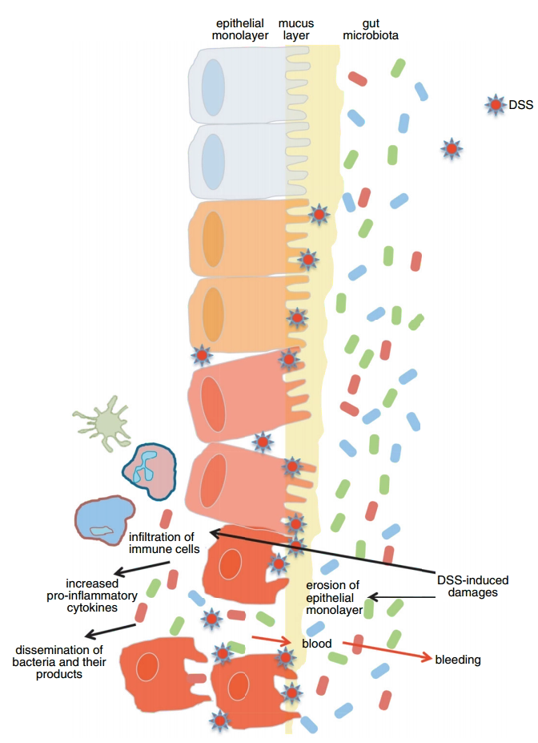

Chassaing et al. (2014). Curr Protoc Immunol. doi:10.1002/0471142735.im1525s104。

## 條件高度受控，結果就一定一致嗎？

**一項針對廣泛使用結腸炎模式的標竿研究**

[figure not shown]

## 相同品系、同一設施：疾病反應仍有巨大落差

**高度標準化的實驗設定：**

- **579 隻**、同一設施飼養的 SPF **C57BL/6N** 雌性小鼠進行 DSS 誘導。

**令人驚訝的表型分歧：**

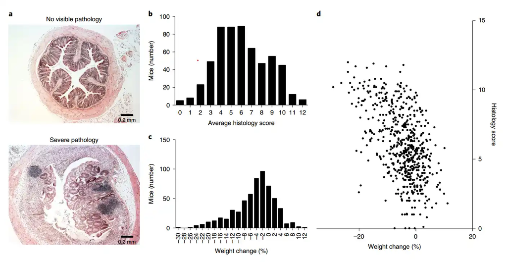

Forster et al. (2022). *Identification of gut microbial species linked with disease variability in a widely used mouse model of colitis.* https://pmc.ncbi.nlm.nih.gov/articles/PMC8975739/

## 變異從何而來？微生物相本身就是模式條件

**無菌鼠糞便移植 (FMT)**

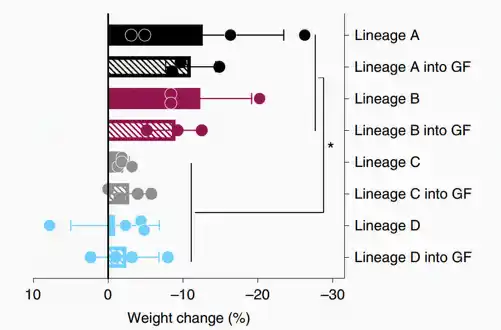

**候選菌株單菌定殖驗證 (Monocolonization)**

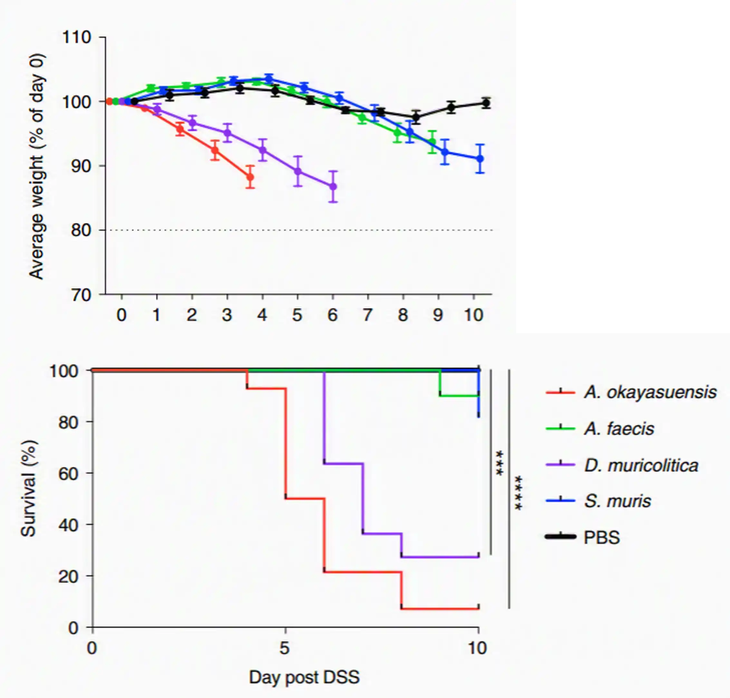

## 案例解析：實驗條件如何決定推論的邊界？

**本研究設定的條件：**

- 就算**遺傳背景相同**，小鼠的疾病反應依然可能差很多
- **腸道菌相與飼養設施**，直接左右了模式的表型表現
- 看到的極端差異可能來自**個體菌相背景**，而非介入處置的效果

***結論外推的限制：**

- 論文必須清楚說明**小鼠來源、設施環境與微生物相 metadata**
- 缺乏這些監測資料時，**絕不能直接把結論套用到其他設施**

評估動物研究時，必須檢視那些  
「沒被寫在論文標題上、卻實質存在」  
的隱藏環境與微生物條件。

Forster et al. (2022). *Identification of gut microbial species linked with disease variability in a widely used mouse model of colitis.* https://pmc.ncbi.nlm.nih.gov/articles/PMC8975739/

## 案例解析：大規模的豬場田間試驗

[figure not shown]

**當得出自家疫苗「無效」的結論，是否能夠推廣到其他豬場？**

## 豬場田間試驗：真實場域中的隨機對照試驗

**研究問題：**

- 在有跛行病史的肥育豬場，自家疫苗能否降低治療率？

**試驗條件與分組：**

- **規模與對照**：737 頭豬（隨機、雙盲、生理食鹽水安慰劑對照）
- **免疫時程**：6 週齡與 9 週齡各進行一次肌肉注射

**觀察端點與結果：**

- **主要指標**：記錄因跛行接受 tiamulin 治療的比例
- **試驗結果**：疫苗組 **7.8%** vs. 對照組 **6.8%** (*p = 0.354*)
- **統計結論**：未觀察到自體疫苗具有顯著保護效果

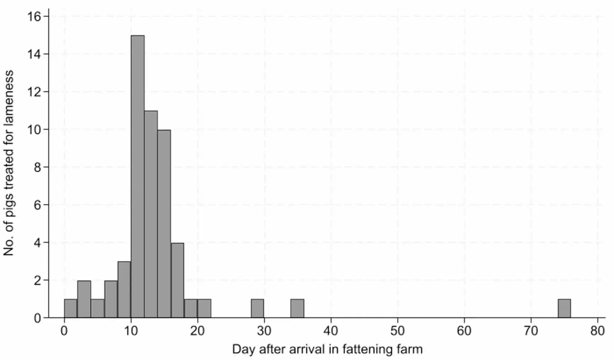

發病高峰集中在進場後第 10–16 天  
(約 11–12 週齡)

## 案例解析：田間試驗的結論能推多遠？

**本研究設定的條件**

- **商業肥育豬場**
  - 面對現場真實的飼養管理與自然感染壓力。
- **貼近現場的臨床指標**
  - 以「是否因跛行需打針治療」作為評估標準。
- **高場域真實性**
  - 研究目標即肉豬本身，非跨物種代理。

**結論外推的限制**

- **單一場域限制**
  - 不同豬場的品系、管理方式、毒株與發病日齡都有落差。
- **未經病原確診**
  - 未採關節液檢驗；跛行可能混雜其他腳蹄或外傷問題。
- **免疫時間窗口**
  - 發病集中於進場 10–16 天，疫苗保護力可能尚未建立。

💡 田間試驗雖然貼近現場，但  
**「這場沒效」不等於「自家疫苗完全沒用」**。

## 研究情境不同，角色也不同

| 研究情境 | 動物 實驗？ | 動物 模式？ | 判斷關鍵（為什麼？） |
| --- | --- | --- | --- |
| **肉豬自家疫苗田間試驗** | **是** | **否** | **目標物種本身**：目的在於評估現場肉豬治療率，研究對象即最終應用對象。 |
| 豬隻人工接種 *M. hyosynoviae* | **是** | **是** | **跨物種代理**：若用來模擬人類關節炎之病理反應或評估新藥，豬即為人類疾病模式。 |
| DSS 小鼠腸炎 (小鼠生物學/福祉) | **是** | **否** | **目標為小鼠本身**：評估小鼠特定品系對化學毒性的耐受劑量或止痛效果，無代理外推。 |
| DSS 小鼠腸炎 (人類 IBD 藥物評估) | **是** | **是** | **病理機制代理**：以化學性急性上皮損傷，作為人類發炎性腸道疾病特定病理環節的代理。 |

**💡**：判斷是不是「模式」，不看物種 (豬或老鼠)，看**研究問題的推論對象是誰**。

## 研究設計的取捨：實驗控制 vs. 現場真實性

任何研究設計，都只能在特定條件下回答問題的一部分：

| 研究設計 | 具體實例 | 可回答的問題 | 結論外推的限制 |
| --- | --- | --- | --- |
| **實驗室人工攻毒** [高實驗控制] | DSS 小鼠腸炎、 人工攻毒豬 | **微觀機制與因果驗證** 變因單純、條件高度標準化 | **缺乏現場真實性** 難以反映田間自然發病與複合環境 |
| **同欄接觸感染** [中度控制] | 混欄接觸試驗 | **自然傳播路徑與群體動態** 重現動物間的接觸傳染途徑 | **暴露劑量與時間難精確掌控** 個別動物的感染時間不一 |
| **商業現場試驗** [高現場真實性] | 肉豬自家疫苗田間試驗 | **實際生產與臨床防治成效** 面對真實農場的複雜環境 | **干擾變因多、場域專一性高** 結論僅適用條件相近的場域 |

💡沒有完美的模型，但有貼近「研究問題」需求的動物實驗設計。

## 評估推論範圍：四個判讀問題

評讀文獻或設計研究時，依序問：

### 條件是否完整？

[figure not shown]

- 物種、品系、性別、週齡
- 飼養環境與場域背景交代

### 遺漏哪些干擾？

[figure not shown]

- 真實環境中被簡化的因素
- 自然暴露、共感染、環境緊迫、菌相

### 指標能否對應？

[figure not shown]

- 量測端點能否回答核心問題
- 體重下降 $\neq$ 腸炎；跛行 $\neq$ 確診病原

### 結論是否外推？

[figure not shown]

- 是特定條件下的局部觀察？
- 還是過度延伸為所有動物都適用？

**看限制不是為了否定研究，而是看清它把問題往前推進了哪一步。**

## Experimental Design Assistant (EDA)：把研究條件畫出來

- NC3Rs 開發的免費線上工具
- 用圖整理動物條件、處置、觀察指標與分析
- 幫助檢查研究問題、條件與端點是否連得起來

今天不操作 EDA；先把它當成閱讀與整理研究設計的視覺化框架。

[figure not shown]

NC3Rs [Experimental Design Assistant.](https://eda.nc3rs.org.uk/)

## 先定位你的 anchor paper

先從研究問題，釐清這篇論文的研究對象與結論範圍。

1. 研究直接關心的對象、族群或情境是什麼？
2. 研究中使用的動物或族群是什麼？
3. 作者希望把結果主要說到哪裡？

## Anchor paper 練習｜動物研究條件盤點

請回到自己的 anchor paper，先找出：

1. 動物來源與遺傳背景：物種、品系、特定建立的動物品系或品種
2. 年齡、性別、體重、生理或疾病階段
3. 飼養與生物背景：飼養條件、飲食、微生物相、環境或田間條件
4. 研究處置：介入、攻毒或誘導、暴露與操作程序
5. 主要觀察指標與觀察期間

> ⚠️ **找不到的資訊更要記下來！**  
> 缺漏的條件，往往就是該研究推論邊界的盲點。

## Anchor paper 練習｜結論範圍

用兩句話整理你的論文：

1. 本研究在……條件下，可以支持關於……的結論。
2. 本研究不能直接推論……，因為……。

理由可從這四項中選一項：

- 因為使用的動物是……
- 因為暴露條件是……
- 因為測量端點是……
- 因為研究情境是……

## 本週重點

1. 先辨認動物在研究中的角色：目標物種、動物模式，或兩者兼具。
2. 解讀研究限制時，要回到研究問題、動物條件與觀察端點。
3. 結論必須符合實際使用的條件與資料能支持的範圍。

## 下週前的閱讀準備

請帶著兩個問題閱讀：

1. 作者真正要回答的研究問題 是什麼？
2. 主要端點是否足以支持作者最後的結論？

下週會把大題目改寫成研究問題、研究目的、假說、主要端點與結論範圍。

## 本週參考資料與延伸閱讀

**本週案例**

- [Chassaing, B. et al. (2014). Dextran Sulfate Sodium (DSS)-Induced Colitis in Mice. *Current Protocols in Immunology*](https://doi.org/10.1002/0471142735.im1525s104)
- [Forster, S. C. et al. (2022). Identification of gut microbial species linked with disease variability in a widely used mouse model of colitis. *Nature Microbiology*](https://doi.org/10.1038/s41564-022-01094-z)
- [Maaland, M. G., & Oropeza-Moe, M. (2026). Randomized controlled single-farm field evaluation of an autogenous *Mycoplasma hyosynoviae* bacterin. *Porcine Health Management*](https://doi.org/10.1186/s40813-026-00503-7)

**研究設計與延伸閱讀**

- [Festing, M. F. W., & Altman, D. G. (2002). Guidelines for the design and statistical analysis of experiments using laboratory animals. *ILAR Journal*](https://doi.org/10.1093/ilar.43.4.244)
- [Würbel, H. (2017). More than 3Rs: The importance of scientific validity for harm-benefit analysis of animal research. *Lab Animal*](https://doi.org/10.1038/laban.1220)
- [Percie du Sert, N. et al. (2020). The ARRIVE guidelines 2.0: Updated guidelines for reporting animal research. *PLOS Biology*](https://doi.org/10.1371/journal.pbio.3000410)
- [NC3Rs Experimental Design Assistant.](https://eda.nc3rs.org.uk/)
- 中華實驗動物學會主編（2020）。《實驗動物科學：基礎篇》。

## 延伸｜常見研究動物：為什麼選牠？

| 類型 | 常見研究優勢 | 讀論文時先留意 |
| --- | --- | --- |
| 小鼠與大鼠 | 遺傳工具、既有疾病模式、可比較的背景資料 | 品系、性別、年齡、微生物相與籠位條件 |
| 兔、豬與其他經濟動物 | 解剖、生理、飼養或臨床情境較貼近特定問題 | 品種、成長期、群養與場域條件 |
| 斑馬魚與其他水生動物 | 發育觀察、成像與大量個體研究 | 水系、健康監測、密度與設施條件 |
| 鳥類與其他非典型模式物種 | 與目標宿主的物種相關性 | 可用試劑、基因體註解、臨床與病理端點 |

## 延伸｜同一物種、不同研究條件

以同樣的小鼠研究為例，至少可能差在：

- 品系或遺傳背景
- 年齡、性別與疾病階段
- 飼料、微生物相與健康狀態
- 單籠或群養、籠位與操作時間
- 誘導方式、劑量與觀察時間